# Final Project Data Script Rmd

Zach Farley, Elizabeth Bates, & Esmeralda Castro

12/08/2021

```r
demographics <- import(here("data", "Teen-Demographic-SPSS(1) copy.zip"))

phys_act <- import(here("data", "Teen-PA-SPSS(1) copy.zip"))
```

# Data Cleaning

## Joined Data

*Our data was split into two files for size/downloadable reasons: adolescent demographic and adolescent physical activity surveys. Each of these files contained a column containing the variable “PID”, or participant identification. The PIDs are unique to each individual who completed the surveys. We used this variable to join these two data sets. This was done using the full join function from the dplyr package. This was used so we could retain all variables contained within both data sets for each specific participant identified by their unique PID. After fully joining these two data sets, we then needed to tidy up data using functions from the tidyverse and dplyr packages* ## Cleaning data - {select}, {characterize}, and {filter} *We then wanted to characterize only select variables, hence the use of the {select}–> {characterize} functions. We could not find a way to characterize the data set as a whole without turning some variables’ values to NA, so we selected certain variables, characterized them, then rejoined the data sets with the newly characterized data.*

```r
joined_set <- demographics %>% full_join(phys_act, by = "PID")

join1 <- joined_set %>%
  as_tibble() %>%
  select(PID, TSEX, TSCHLTYPE, TETHRAC_RC, TGRADE, TAGE) %>%
  characterize(c(TSEX, TSCHLTYPE, TETHRAC_RC, TGRADE, TAGE))

join2 <- joined_set %>%
  select(PID,XTHEIGHTCM_RC, XTWEIGHTKG_RC, TETHRAC_RC, TPMPABAD, TPMPAWANT, TPMPAUPST, TPMPAIMPT, XTPREDWEEKS, XTPREDWEEKOFS, XTPREDWEEKW, TAGE)

full_joined_set <- join2 %>% full_join(join1, by = "PID")
```

## Convert “-9” to “NA” and ridding any rows with “NAs”

```r
final_joined <- full_joined_set %>%
  replace_with_na_all(condition = ~.x == -9) %>%
  na.omit(full_joined_set)
```

## Ages 13-18 (teenagers) only {filter}

```r
teenage_only <- final_joined %>%
  filter(TAGE.x >= 3)
```

## Teenagers With BMI Calculated {mutate}

*To calculate BMI, we utilized the {mutate} function* **teen_w_bmi_1** is our cleaned data set. *We completed {pivot_wider} and {pivot_longer} but did not include in the cleaned data set because it made it ‘messy’.*

```r
teen_w_bmi <- teenage_only %>%
  mutate(height_meters = XTHEIGHTCM_RC / 100) %>%
  mutate(bmi = XTWEIGHTKG_RC/(height_meters^2)) %>%
  mutate(total_pa_wk_min = XTPREDWEEKOFS + XTPREDWEEKW)

teen_w_bmi_1 <- subset(teen_w_bmi, TSEX!="Not ascertained")
teen_w_bmi_1 <- subset(teen_w_bmi_1, TSCHLTYPE!="Not ascertained")
teen_w_bmi_1 <- subset(teen_w_bmi_1, TGRADE!="Not ascertained")
```

## Calculating Mean Physical Activity and Mean Age according to school type and sex- {summarize} and {group_by}

*The {group_by} function allowed us to organize our data by school type and sex to calculate mean physical activity and mean age. This grouping was helpful for our description of the relevant data for our research questions. We ultimately did not ask a research question regarding when physical activity was completed - in school, out of school, or on weekend, but kept in the code because it is interesting).*

```r
grouped_data <- teen_w_bmi_1 %>%
  group_by(TSCHLTYPE, TSEX) %>%
  summarize(mean_age = round(mean(TAGE.x + 10), digits = 2),
            mean_total_PA = round(mean(total_pa_wk_min), digits = 2)) %>%
  kable()

teen_w_bmi_1$TSCHLTYPE <- as.factor(teen_w_bmi_1$TSCHLTYPE) #school type
levels(teen_w_bmi$TSCHLTYPE)
```

```r
rev_teen_w_bmi_1 <- teen_w_bmi_1%>%
   group_by(TSCHLTYPE, TSEX) %>%
  mutate(mean_age = round(mean(TAGE.x + 10), digits = 2),
            mean_total_PA = round(mean(total_pa_wk_min), digits = 2),
         PA_pct_in_school = (mean(XTPREDWEEKS)/mean_total_PA) *100,
         PA_pct_out_school = (mean(XTPREDWEEKOFS)/mean_total_PA) *100,
         PA_pct_wkend = (mean(XTPREDWEEKW)/mean_total_PA)*100)
```

## {pivot_longer} for organzing when physical activity occurs

*The initial data set divided when physical activity was completed by during the week in school (XTPREDWEEKS), during the week out of school (XTPREDWEEKOFS), and on the weekend(XTPREDWEEKW). Using {pivot_longer}, we combined the variables of when/where the physical activity was completed to explore when/where physical activity was completed across different school types and demographic variables. We used various ggplot functions to visualize the data and associations.*

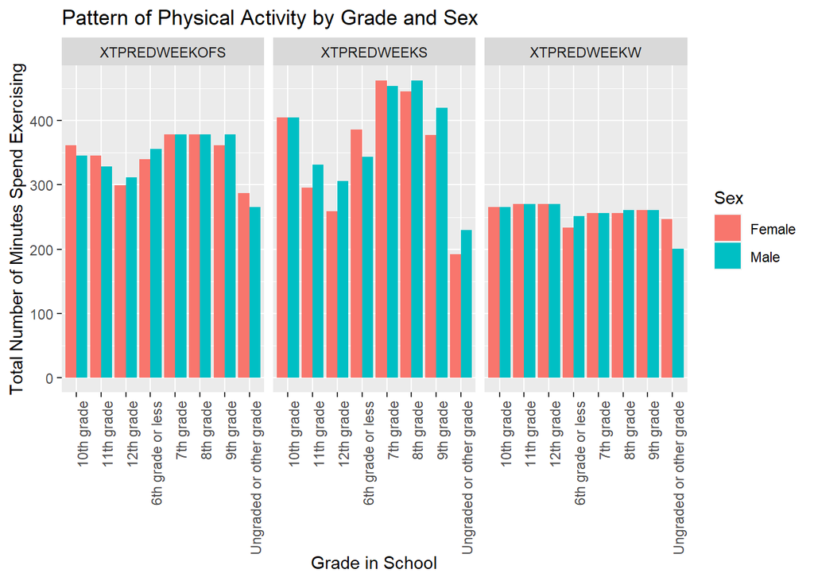

```r
longer_teen_bmi_1 <- teen_w_bmi_1 %>%
  pivot_longer(
    cols = starts_with("XTPREDWEEK"),
    names_to = "MVPA_when",
    values_to = "minutes",
    values_drop_na = TRUE) %>%
  select(PID, TSEX, TGRADE, TSCHLTYPE, MVPA_when, minutes)

#Column Plot to show break down of when physical activity is completed by grade and sex
longer_teen_bmi_1 %>%
  ggplot(aes(TGRADE, minutes))+
  geom_col(aes(fill=TSEX),
           position= "dodge") +
  facet_wrap(~MVPA_when) +
  theme(axis.text.x = element_text(angle=90, hjust = 1)) +
  labs(title= "Pattern of Physical Activity by Grade and Sex",
       x= "Grade in School",
       y= "Total Number of Minutes Spend Exercising",
       fill= "Sex")
```

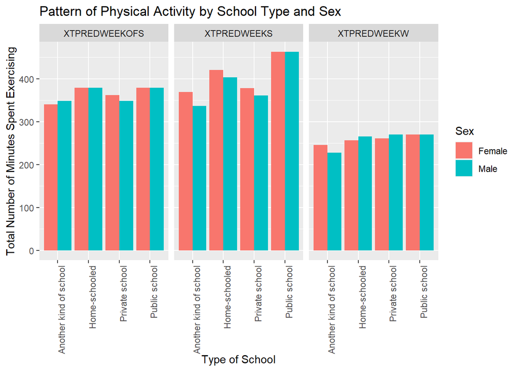

```r
#Column plot to show when physical activity is completed by type of school and sex
longer_teen_bmi_1 %>%
  ggplot(aes(TSCHLTYPE, minutes))+
  geom_col(aes(fill=TSEX),
           position= "dodge") +
  facet_wrap(~MVPA_when) +
  theme(axis.text.x = element_text(angle=90, hjust = 1)) +
  labs(title= "Pattern of Physical Activity by School Type and Sex",
       x= "Type of School",
       y= "Total Number of Minutes Spent Exercising",
       fill= "Sex")
```

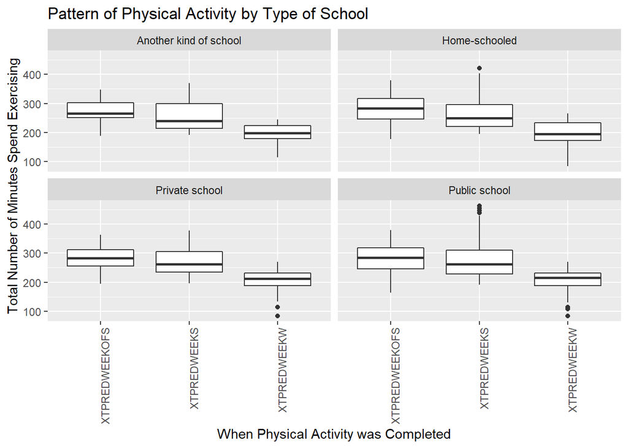

```r
#Box plot to show when physical activity was completed by school type
longer_teen_bmi_1 %>%
  ggplot(aes(MVPA_when, minutes)) +
  geom_boxplot() +
  facet_wrap(~TSCHLTYPE) +
  theme(axis.text.x = element_text(angle=90, hjust = 1)) +
  labs(title= "Pattern of Physical Activity by Type of School",
       x= "When Physical Activity was Completed",
       y= "Total Number of Minutes Spend Exercising")
```

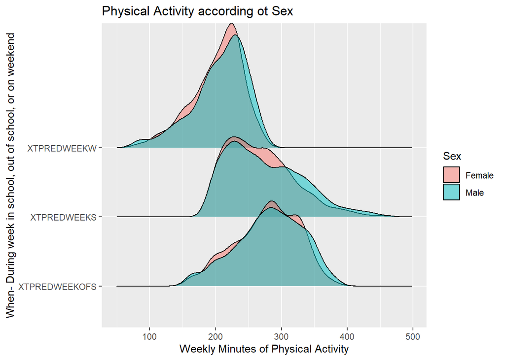

```r
#this one is pretty cool to show differences by sex and school type - answer- no difference!
ggplot(longer_teen_bmi_1, aes(minutes, MVPA_when)) +
  geom_density_ridges(aes(fill = factor(TSEX)),
                        alpha= 0.5) +
  labs(title = "Physical Activity according ot Sex",
       x= "Weekly Minutes of Physical Activity",
       y= "When- During week in school, out of school, or on weekend",
       fill= "Sex")
```

##{pivot_wider} for School Type *Because of the relatively clean data set and types of variables we have, it was challenging to find a useful way to incorporate {pivot_wider} for our research questions. So, we experimented with {pivot_wider} with the TSCHLTYPE variable and broke it down into each school type with participants’ total minutes of physical activity by week and the average physical activity. It succeeded in pivoting wider and organizing the mean and total weekly physical activity by school type. However, because each participant only attended one school, there are ‘NA’ values for the schools they did not attend, making the resulting data frame appear messier. After much trial and error, we resolved that we cannot remove the ’NA’s at this time, because they are necessary for the formatting of the data set.*

```r
wider_teen_bmi_1 <- teen_w_bmi_1 %>%
  select(PID, TSCHLTYPE, total_pa_wk_min) %>%
  group_by(TSCHLTYPE) %>%
  mutate(mean_totalpa = mean(total_pa_wk_min)) %>%
  pivot_wider(names_from = TSCHLTYPE,
    values_from = total_pa_wk_min)
```

# Summary Table

```r
summary_table1 <- teen_w_bmi_1 %>%
  group_by(TSCHLTYPE,TSEX) %>%
  summarize(mean_age=mean(TAGE.x +10), mean_bmi= mean(bmi), mean_weekofs= mean(XTPREDWEEKOFS), mean_weekw= mean(XTPREDWEEKW),  mean_total_pa_wk_min = mean(total_pa_wk_min)) %>%
  kable(caption = "Table 2. Pattern of Physical Activity by School Type",
        col.names = c("School Type", "Sex", "Mean age", "Mean BMI","Mean minutes of PA out of School","Mean minutes of PA on weekend",  "Mean Weekly Minutes of PA"))
```

# Visualizations

## First Visualization

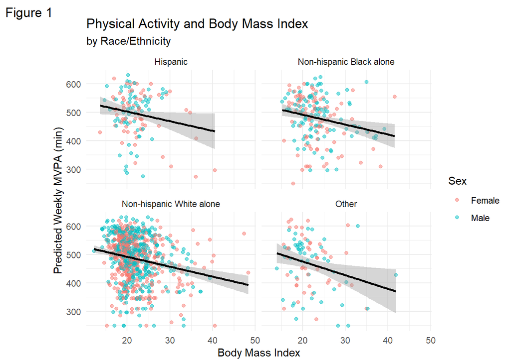

```r
teen_w_bmi_1 %>%
  ggplot(aes(bmi, total_pa_wk_min)) +
  geom_point(aes(color = TSEX), alpha = 0.5) +
  geom_smooth(method = lm, color = "black") +
  facet_wrap(~TETHRAC_RC.y) +
  theme_minimal() +
  labs(y = "Predicted Weekly MVPA (min)",
       x = "Body Mass Index",
       title = "Physical Activity and Body Mass Index",
       subtitle = "by Race/Ethnicity",
       color = "Sex",
       tag = "Figure 1")
```

## Second Visualization

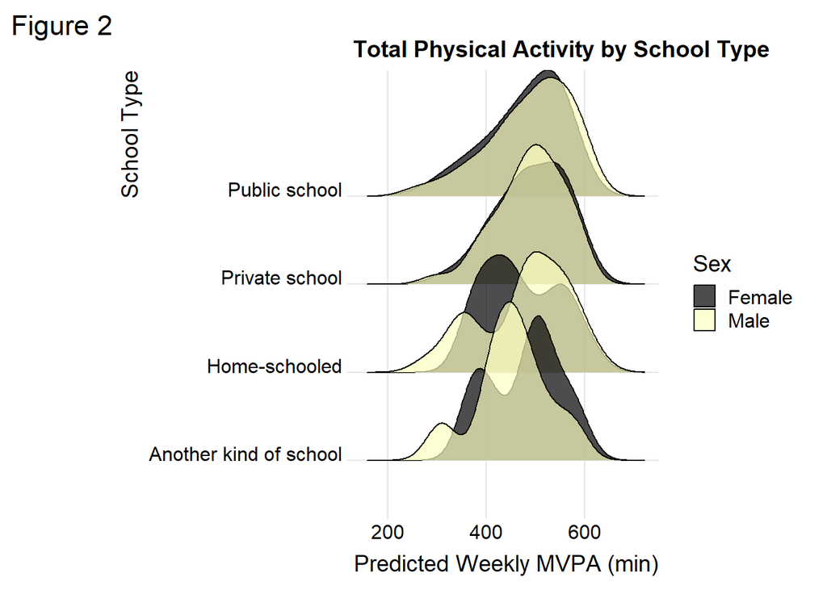

```r
teen_w_bmi_1 %>%
  ggplot(aes(total_pa_wk_min, TSCHLTYPE)) +
  geom_density_ridges(aes(fill = factor(TSEX)),
                      alpha = 0.7) +
  scale_fill_viridis_d(option = "magma", name = "Sex") +
  theme_ridges() +
  labs(title = "Total Physical Activity by School Type",
       y = "School Type",
       x = "Predicted Weekly MVPA (min)",
       tag = "Figure 2")
```

Down here is Zach messing around with an ANOVA

```r
teen_w_bmi_1 %>%
  group_by(TSCHLTYPE) %>%
  summarise(count = n(),
            mean = mean(total_pa_wk_min),
            sd = sd(total_pa_wk_min))
```

```
## # A tibble: 4 x 4
##   TSCHLTYPE              count  mean    sd
##   <fct>                  <int> <dbl> <dbl>
## 1 Another kind of school    18  465.  73.9
## 2 Home-schooled             65  475.  84.2
## 3 Private school            84  491.  70.0
## 4 Public school           1025  484.  82.8
```

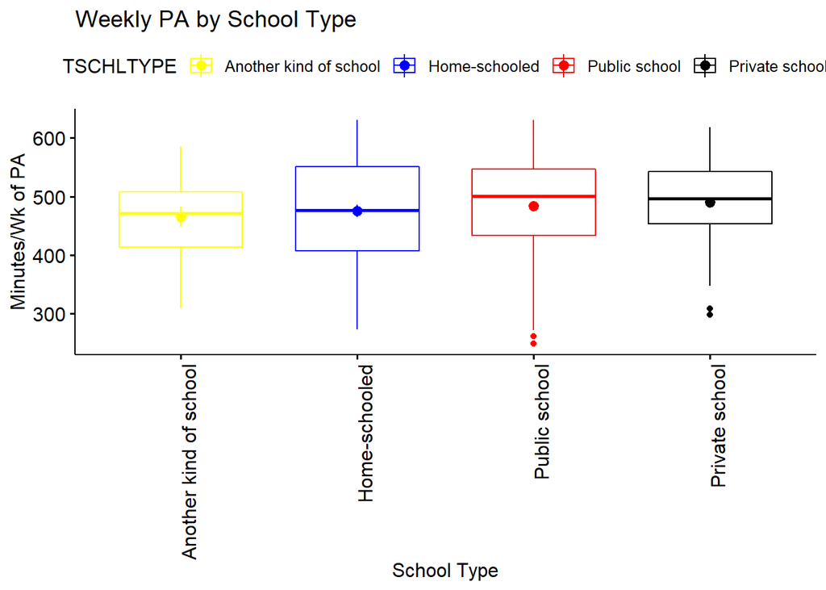

```r
library(ggpubr)

teen_w_bmi_1 %>%
  ggboxplot(x = "TSCHLTYPE", y = "total_pa_wk_min",
            add = c("mean_se"),
            color = "TSCHLTYPE",
            palette = c("yellow",
                        "blue",
                        "red",
                        "black"),
            order = c("Another kind of school",
                      "Home-schooled",
                      "Public school",
                      "Private school"),
            ylab = "Minutes/Wk of PA",
            xlab = "School Type",
            title = "Weekly PA by School Type") +
  theme(axis.text.x = element_text(angle=90, hjust = 1))
```

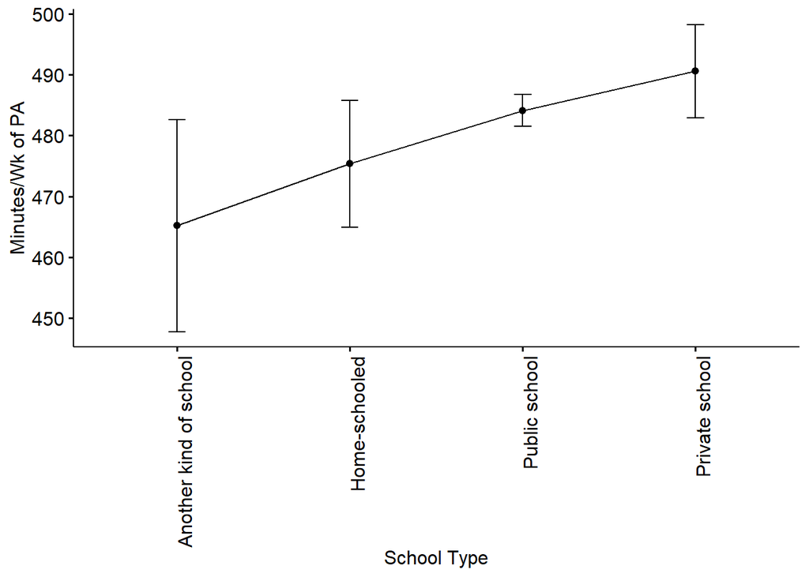

```r
teen_w_bmi_1 %>%
  ggline(x = "TSCHLTYPE",
         y = "total_pa_wk_min",
       add = c("mean_se"),
       order = c("Another kind of school",
                 "Home-schooled",
                 "Public school",
                 "Private school"),
       ylab = "Minutes/Wk of PA",
       xlab = "School Type") +
  theme(axis.text.x = element_text(angle=90, hjust = 1))
```

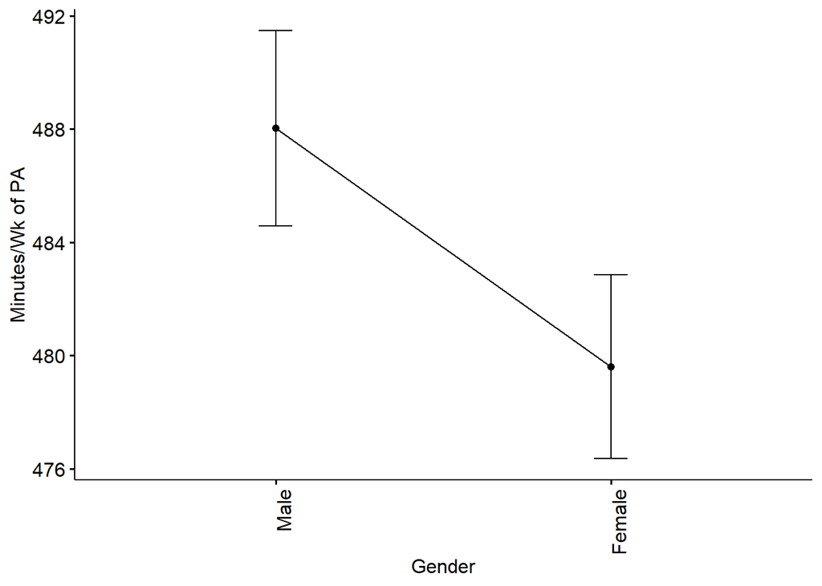

```r
# Differnece in MVPA by Gender

teen_w_bmi_1 %>%
  ggline(x = "TSEX",
         y = "total_pa_wk_min",
       add = c("mean_se"),
       order = c("Male",
                 "Female"),
       ylab = "Minutes/Wk of PA",
       xlab = "Gender") +
  theme(axis.text.x = element_text(angle=90, hjust = 1))
```

```r
# No significant difference in weekly PA between school type
anova_school <- aov(total_pa_wk_min ~ TSCHLTYPE, data = teen_w_bmi_1)
summary(anova_school)
```

```
##               Df  Sum Sq Mean Sq F value Pr(>F)
## TSCHLTYPE      3   14801    4934   0.736  0.531
## Residuals   1188 7966263    6706
```

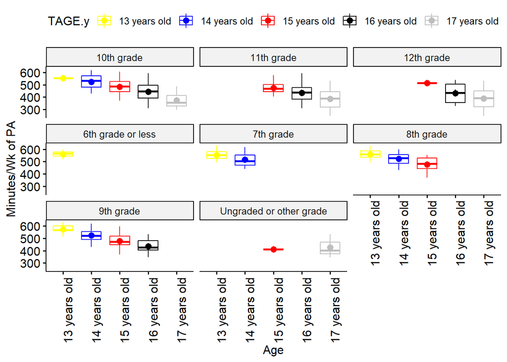

```r
# This shows that the younger one is, the greater the MVPA/WK regardless of grade
teen_w_bmi_1 %>%
  ggboxplot(x = "TAGE.y",
            y = "total_pa_wk_min",
            add = c("mean_se"),
            color = "TAGE.y",
            palette = c("yellow", "blue",
                        "red", "black",
                        "grey"),
            order = c("13 years old", "14 years old",
                      "15 years old", "16 years old",
                      "17 years old"),
            ylab = "Minutes/Wk of PA",
            xlab = "Age") +
  facet_wrap(~TGRADE) +
  theme(axis.text.x = element_text(angle=90, hjust = 1))
```

```r
# Significant differences in PA min/wk based upon age
anova_age <- aov(total_pa_wk_min ~ TAGE.y, data = teen_w_bmi_1)
summary(anova_age)
```

```
##               Df  Sum Sq Mean Sq F value Pr(>F)
## TAGE.y         4 3965914  991479   293.1 <2e-16 ***
## Residuals   1187 4015150    3383
## ---
## Signif. codes:  0 '***' 0.001 '**' 0.01 '*' 0.05 '.' 0.1 ' ' 1
```

```r
tukey_age <- TukeyHSD(anova_age)
# This shows full p-values. all are p < .05
print(tukey_age, digits = 20)
```

```
##   Tukey multiple comparisons of means
##     95% family-wise confidence level
##
## Fit: aov(formula = total_pa_wk_min ~ TAGE.y, data = teen_w_bmi_1)
##
## $TAGE.y
##                                           diff                  lwr
## 14 years old-13 years old  -35.442465915361595  -49.703620401855027
## 15 years old-13 years old  -76.859705494005425  -90.821249959836152
## 16 years old-13 years old -119.099801327448006 -132.458013047543545
## 17 years old-13 years old -170.781971478343110 -186.466690781333085
## 15 years old-14 years old  -41.417239578643830  -56.181108360132129
## 16 years old-14 years old  -83.657335412086411  -97.852014622429067
## 17 years old-14 years old -135.339505562981515 -151.742478377054653
## 16 years old-15 years old  -42.240095833442581  -56.133731587566508
## 17 years old-15 years old  -93.922265984337685 -110.065429048711394
## 17 years old-16 years old  -51.682170150895104  -67.306472062036249
##                                            upr                  p adj
## 14 years old-13 years old  -21.181311428868163 1.7720980239000000e-10
## 15 years old-13 years old  -62.898161028174698 0.0000000000000000e+00
## 16 years old-13 years old -105.741589607352466 0.0000000000000000e+00
## 17 years old-13 years old -155.097252175353134 0.0000000000000000e+00
## 15 years old-14 years old  -26.653370797155532 3.9934721999999998e-13
## 16 years old-14 years old  -69.462656201743755 0.0000000000000000e+00
## 17 years old-14 years old -118.936532748908377 0.0000000000000000e+00
## 16 years old-15 years old  -28.346460079318653 4.5408120000000003e-14
## 17 years old-15 years old  -77.779102919963975 0.0000000000000000e+00
## 17 years old-16 years old  -36.057868239753965 3.5638159999999997e-14
```

```r
#Make output as a table
library(broom)
tidy_tukey <- tidy(tukey_age, digits = 20)

tidy_tukey %>%
  kable(digits = 15)
```

| term | contrast | null.value | estimate | conf.low | conf.high | adj.p.value |
| --- | --- | --- | --- | --- | --- | --- |
| TAGE.y | 14 years old-13 years old | 0 | -35.44247 | -49.70362 | -21.18131 | 1.7721e-10 |
| TAGE.y | 15 years old-13 years old | 0 | -76.85971 | -90.82125 | -62.89816 | 0.0000e+00 |
| TAGE.y | 16 years old-13 years old | 0 | -119.09980 | -132.45801 | -105.74159 | 0.0000e+00 |
| TAGE.y | 17 years old-13 years old | 0 | -170.78197 | -186.46669 | -155.09725 | 0.0000e+00 |
| TAGE.y | 15 years old-14 years old | 0 | -41.41724 | -56.18111 | -26.65337 | 3.9900e-13 |
| TAGE.y | 16 years old-14 years old | 0 | -83.65734 | -97.85201 | -69.46266 | 0.0000e+00 |
| TAGE.y | 17 years old-14 years old | 0 | -135.33951 | -151.74248 | -118.93653 | 0.0000e+00 |
| TAGE.y | 16 years old-15 years old | 0 | -42.24010 | -56.13373 | -28.34646 | 4.5000e-14 |
| TAGE.y | 17 years old-15 years old | 0 | -93.92227 | -110.06543 | -77.77910 | 0.0000e+00 |
| TAGE.y | 17 years old-16 years old | 0 | -51.68217 | -67.30647 | -36.05787 | 3.6000e-14 |